# Assignment 4: Spatial Predictive Analysis

## Kernal Density Basemap

```r
# Convert burglaries to ppp (point pattern) format for spatstat
burglaries_ppp <- as.ppp(
  st_coordinates(burglaries),
  W = as.owin(st_bbox(chicagoBoundary))
)

# Calculate KDE with 1km bandwidth
kde_burglaries <- density.ppp(
  burglaries_ppp,
  sigma = 1000,  # 1km bandwidth
  edge = TRUE    # Edge correction
)

# Convert to terra raster (modern approach, not raster::raster)
kde_raster <- rast(kde_burglaries)

# Extract KDE values to fishnet cells
fishnet <- fishnet %>%
  mutate(
    kde_value = terra::extract(
      kde_raster,
      vect(fishnet),
      fun = mean,
      na.rm = TRUE
    )[, 2]  # Extract just the values column
  )

cat("✓ Calculated KDE baseline\n")
```

```
✓ Calculated KDE baseline
```

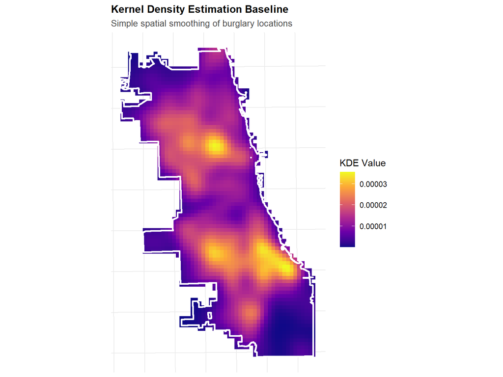

```r
ggplot() +
  geom_sf(data = fishnet, aes(fill = kde_value), color = NA) +
  geom_sf(data = chicagoBoundary, fill = NA, color = "white", linewidth = 1) +
  scale_fill_viridis_c(
    name = "KDE Value",
    option = "plasma"
  ) +
  labs(
    title = "Kernel Density Estimation Baseline",
    subtitle = "Simple spatial smoothing of burglary locations"
  ) +
  theme_crime()
```

The above map looks very similar to the other patterns of crime in Chicago because a KDE baseline looks as what happens if an incident, in this case burglaries happens where they did before. This map counts the clusters of incidents well.

## Spatial predictor variables

```r
streetLights_allOut <- read_csv(here("data/311_Service_Requests_-_Street_Lights_-_All_Out_-_Historical_20251112.csv"))%>%
  filter(!is.na(Latitude), !is.na(Longitude)) %>%
  st_as_sf(coords = c("Longitude", "Latitude"), crs = 4326) %>%
  st_transform('ESRI:102271')

#cat("✓ Loaded street vehicle calls\n")
cat("  - Number of calls:", nrow(streetLights_allOut), "\n")
```

```
  - Number of calls: 296511
```

```r
"data/311_Service_Requests_-_Street_Lights_-_All_Out_-_Historical_20251112.csv"
```

```
[1] "data/311_Service_Requests_-_Street_Lights_-_All_Out_-_Historical_20251112.csv"
```

## Count of Street Lights all out per cell

```r
# Aggregate lights out to fishnet
lights_fishnet <- st_join(streetLights_allOut, fishnet, join = st_within) %>%
  st_drop_geometry() %>%
  group_by(uniqueID) %>%
  summarize(streetLights_allOut = n())

# Join to fishnet
fishnet <- fishnet %>%
  left_join(lights_fishnet, by = "uniqueID") %>%
  mutate(streetLights_allOut = replace_na(streetLights_allOut, 0))

cat("All lights out distribution:\n")
```

```
All lights out distribution:
```

```r
summary(fishnet$streetLights_allOut)
```

```
   Min. 1st Qu.  Median    Mean 3rd Qu.    Max.
    0.0    38.0   102.0   120.4   175.8   706.0
```

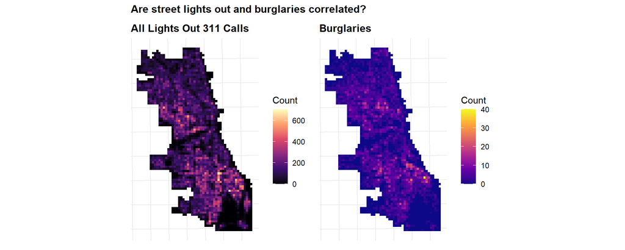

```r
p1 <- ggplot() +
  geom_sf(data = fishnet, aes(fill = streetLights_allOut), color = NA) +
  scale_fill_viridis_c(name = "Count", option = "magma") +
  labs(title = "All Lights Out 311 Calls") +
  theme_crime()

p2 <- ggplot() +
  geom_sf(data = fishnet, aes(fill = countBurglaries), color = NA) +
  scale_fill_viridis_c(name = "Count", option = "plasma") +
  labs(title = "Burglaries") +
  theme_crime()

p1 + p2 +
  plot_annotation(title = "Are street lights out and burglaries correlated?")
```

In this section I pulled data from Chicago’s Open Data portal for 311 calls on street lights that are all out. Visually there are similarities between where burglairies occur and where street lights are all out specifically on the South Side there is more difference between these two categories in the North. This suggests that where street lights are out could help predict burglaries, but more likely just implies perceptions of safety.

## Nearest Neighbor

Here we are calculating the mean distance to the 3 nearest blockw with all the lights out.

```r
# Calculate mean distance to 3 nearest lights out
# (Do this OUTSIDE of mutate to avoid sf conflicts)

# Get coordinates
fishnet_coords <- st_coordinates(st_centroid(fishnet))
lights_coords <- st_coordinates(streetLights_allOut)

# Calculate k nearest neighbors and distances
nn_result <- get.knnx(lights_coords, fishnet_coords, k = 3)

# Add to fishnet
fishnet <- fishnet %>%
  mutate(
    streetLights_allOut.nn = rowMeans(nn_result$nn.dist)
  )

cat("✓ Calculated nearest neighbor distances\n")
```

```
✓ Calculated nearest neighbor distances
```

```r
summary(fishnet$streetLights_allOut.nn)
```

```
     Min.   1st Qu.    Median      Mean   3rd Qu.      Max.
   0.9959   38.0172   59.4470  119.7214  110.8656 1436.3413
```

A low value of streetLights_allOut.nn means means that the block is closer to other blocks with the lights out while a high value means that a cell is far from other cells with blocks that have the lights out. Blocks that have low value could indicate decreasing perceptions of safety.

## Distance to Hot Spots

```r
#used this for local_moran becuase when it saves fishnet as fishnet it aborts 2. dplyr mutate + sf can still corrupt the geometry column

coords <- st_coordinates(st_centroid(fishnet))
neighbors <- knn2nb(knearneigh(coords, k = 5))
weights <- nb2listw(neighbors, style = "W", zero.policy = TRUE)

local_moran <- localmoran(fishnet[["streetLights_allOut"]], weights)
mean_val <- mean(fishnet[["streetLights_allOut"]], na.rm = TRUE)

fishnet$local_i <- local_moran[,1]
fishnet$p_value <- local_moran[,5]
fishnet$is_significant <- fishnet$p_value < 0.05

mean_val <- mean(fishnet$streetLights_allOut, na.rm = TRUE)

fishnet$moran_class <- dplyr::case_when(
  !fishnet$is_significant ~ "Not Significant",
  fishnet$local_i > 0 & fishnet$streetLights_allOut > mean_val ~ "High-High",
  fishnet$local_i > 0 & fishnet$streetLights_allOut <= mean_val ~ "Low-Low",
  fishnet$local_i < 0 & fishnet$streetLights_allOut > mean_val ~ "High-Low",
  fishnet$local_i < 0 & fishnet$streetLights_allOut <= mean_val ~ "Low-High"
)
```

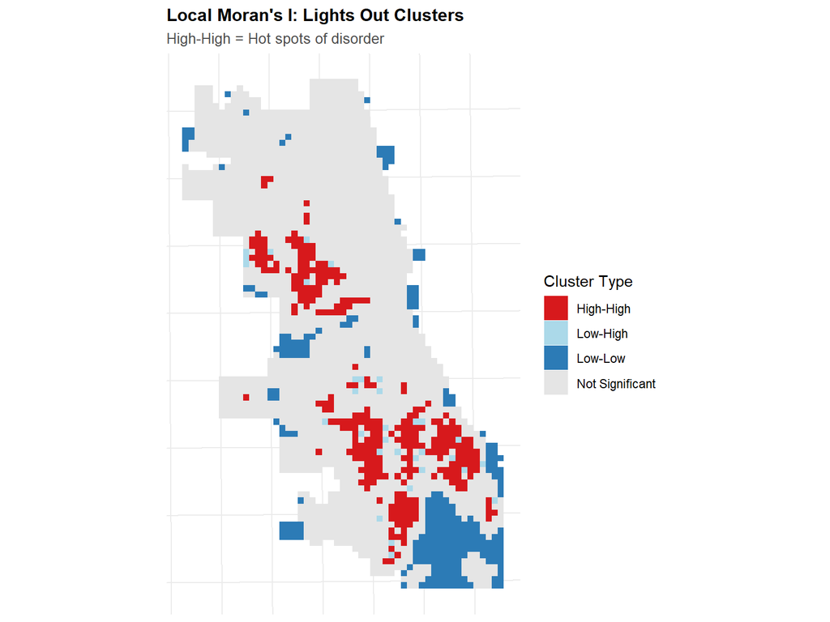

```r
# Visualize hot spots
ggplot() +
  geom_sf(
    data = fishnet,
    aes(fill = moran_class),
    color = NA
  ) +
  scale_fill_manual(
    values = c(
      "High-High" = "#d7191c",
      "High-Low" = "#fdae61",
      "Low-High" = "#abd9e9",
      "Low-Low" = "#2c7bb6",
      "Not Significant" = "gray90"
    ),
    name = "Cluster Type"
  ) +
  labs(
    title = "Local Moran's I: Lights Out Clusters",
    subtitle = "High-High = Hot spots of disorder"
  ) +
  theme_crime()
```

```r
#fill= moran_class is not running
```

The distance to a cluster of lights that are out are helpful because it shows local spatial density while only looking at the distance to one specific point could be a random incident. From the distribution there are no areas with a high-low distribution and few areas with a low-high distribution. Low-low distributions, which are cold spots few lights are out and next to people without lights out, are clustered in the Southeast corner of Chicago, with patches around the boundary of the city. This means there are low values and its surrounded by other low values. High-high clusters are in the center of Chicago suggests that the observations are part of a cluster of high values and surrounded by high values i.e. street light blocks are out and they are next to other areas with street lights that are out. One thing to keep in mind is that the boundaries of Chicago have fewer neighbors thus this could bias the results and result with the spatial outliers such as high-low results.

```r
# Get centroids of "High-High" cells (hot spots)
hotspots <- fishnet %>%
  filter(moran_class == "High-High") %>%
  st_centroid()

# Calculate distance from each cell to nearest hot spot
if (nrow(hotspots) > 0) {
  fishnet <- fishnet %>%
    mutate(
      dist_to_hotspot = as.numeric(
        st_distance(st_centroid(fishnet), hotspots %>% st_union())
      )
    )

  cat("✓ Calculated distance to abandoned car hot spots\n")
  cat("  - Number of hot spot cells:", nrow(hotspots), "\n")
} else {
  fishnet <- fishnet %>%
    mutate(dist_to_hotspot = 0)
  cat("⚠ No significant hot spots found\n")
}
```

```
✓ Calculated distance to abandoned car hot spots
  - Number of hot spot cells: 297
```

There are 297 hot spots.

## Cross Validation

```r
# Join district information to fishnet
fishnet <- st_join(
  fishnet,
  policeDistricts,
  join = st_within,
  left = TRUE
) %>%
  filter(!is.na(District))  # Remove cells outside districts

cat("✓ Joined police districts\n")
```

```
✓ Joined police districts
```

```r
cat("  - Districts:", length(unique(fishnet$District)), "\n")
```

```
  - Districts: 22
```

```r
cat("  - Cells:", nrow(fishnet), "\n")
```

```
  - Cells: 1708
```

Police districts are used for the spatial cross-validation because we are using crime data.

## Poisson Regression

```r
# Create clean modeling dataset
fishnet_model <- fishnet %>%
  st_drop_geometry() %>%
  dplyr::select(
    uniqueID,
    District,
    countBurglaries,
    streetLights_allOut,
    streetLights_allOut.nn,
    dist_to_hotspot
  ) %>%
  na.omit()  # Remove any remaining NAs

cat("✓ Prepared modeling data\n")
```

```
✓ Prepared modeling data
```

```r
cat("  - Observations:", nrow(fishnet_model), "\n")
```

```
  - Observations: 1708
```

```r
cat("  - Variables:", ncol(fishnet_model), "\n")
```

```
  - Variables: 6
```

There are 1708 observations and 6 variables. All of the values are positive because we are counting and cannot have a negative number.

```r
fishnet_safe <- data.frame(
  countBurglaries      = as.numeric(fishnet_model$countBurglaries),
  streetLights_allOut  = as.numeric(fishnet_model$streetLights_allOut),
  streetLights_allOut.nn = as.numeric(fishnet_model$streetLights_allOut.nn),
  dist_to_hotspot      = as.numeric(fishnet_model$dist_to_hotspot)
)

# Remove row.names just in case
rownames(fishnet_safe) <- NULL

# Confirm attributes might not need attributes through glm just need to write.csv so could delete
attributes(fishnet_safe)
```

[output not shown]

[output cut: 115 more lines]

```r
glm(countBurglaries ~ streetLights_allOut, data = fishnet_safe, family = poisson())
```

```
Call:  glm(formula = countBurglaries ~ streetLights_allOut, family = poisson(),
    data = fishnet_safe)

Coefficients:
        (Intercept)  streetLights_allOut
           0.670548             0.003695

Degrees of Freedom: 1707 Total (i.e. Null);  1706 Residual
Null Deviance:      6710
Residual Deviance: 5545     AIC: 9609
```

```r
glm(countBurglaries ~ streetLights_allOut.nn, data = fishnet_safe, family = poisson())
```

```
Call:  glm(formula = countBurglaries ~ streetLights_allOut.nn, family = poisson(),
    data = fishnet_safe)

Coefficients:
           (Intercept)  streetLights_allOut.nn
                1.8609                 -0.0099

Degrees of Freedom: 1707 Total (i.e. Null);  1706 Residual
Null Deviance:      6710
Residual Deviance: 5286     AIC: 9350
```

```r
glm(countBurglaries ~ dist_to_hotspot, data = fishnet_safe, family = poisson())
```

```
Call:  glm(formula = countBurglaries ~ dist_to_hotspot, family = poisson(),
    data = fishnet_safe)

Coefficients:
    (Intercept)  dist_to_hotspot
      1.5780441       -0.0001758

Degrees of Freedom: 1707 Total (i.e. Null);  1706 Residual
Null Deviance:      6710
Residual Deviance: 6165     AIC: 10230
```

```r
glm(countBurglaries ~ streetLights_allOut + streetLights_allOut.nn + dist_to_hotspot,
    data = fishnet_safe, family = poisson())
```

```
Call:  glm(formula = countBurglaries ~ streetLights_allOut + streetLights_allOut.nn +
    dist_to_hotspot, family = poisson(), data = fishnet_safe)

Coefficients:
           (Intercept)     streetLights_allOut  streetLights_allOut.nn
            1.59385399              0.00176658             -0.00744121
       dist_to_hotspot
           -0.00008897

Degrees of Freedom: 1707 Total (i.e. Null);  1704 Residual
Null Deviance:      6710
Residual Deviance: 4784     AIC: 8852
```

```r
write.csv(fishnet_safe, "fishnet_safe.csv", row.names = FALSE)
fishnet_reload <- read.csv("fishnet_safe.csv")

glm(countBurglaries ~ streetLights_allOut + streetLights_allOut.nn + dist_to_hotspot,
    data = fishnet_reload, family = poisson())
```

```
Call:  glm(formula = countBurglaries ~ streetLights_allOut + streetLights_allOut.nn +
    dist_to_hotspot, family = poisson(), data = fishnet_reload)

Coefficients:
           (Intercept)     streetLights_allOut  streetLights_allOut.nn
            1.59385399              0.00176658             -0.00744121
       dist_to_hotspot
           -0.00008897

Degrees of Freedom: 1707 Total (i.e. Null);  1704 Residual
Null Deviance:      6710
Residual Deviance: 4784     AIC: 8852
```

```r
library(speedglm)


model_poisson <- speedglm(
  countBurglaries ~ streetLights_allOut + streetLights_allOut.nn + dist_to_hotspot,
  data = fishnet_reload,
  family = poisson()
)

summary(model_poisson)
```

```
Generalized Linear Model of class 'speedglm':

Call:  speedglm(formula = countBurglaries ~ streetLights_allOut + streetLights_allOut.nn +      dist_to_hotspot, data = fishnet_reload, family = poisson())

Coefficients:
 ------------------------------------------------------------------
                          Estimate  Std. Error z value
(Intercept)             1.59385399 0.044790028   35.59
streetLights_allOut     0.00176658 0.000136858   12.91
streetLights_allOut.nn -0.00744121 0.000389666  -19.10
dist_to_hotspot        -0.00008897 0.000008296  -10.72
                                                                                                                                                                                                                                                                                                         Pr(…
(Intercept)            0.000000000000000000000000000000000000000000000000000000000000…
streetLights_allOut    0.000000000000000000000000000000000000040497175984061512185596…
streetLights_allOut.nn 0.000000000000000000000000000000000000000000000000000000000000…
dist_to_hotspot        0.000000000000000000000000007772330460611182199794771952028327…

(Intercept)            ***
streetLights_allOut    ***
streetLights_allOut.nn ***
dist_to_hotspot        ***

-------------------------------------------------------------------
Signif. codes:  0 '***' 0.001 '**' 0.01 '*' 0.05 '.' 0.1 ' ' 1

---
null df: 1707; null deviance: 6710.26;
residuals df: 1704; residuals deviance: 4784.14;
# obs.: 1708; # non-zero weighted obs.: 1708;
AIC: 8852.478; log Likelihood: -4422.239;
RSS: 5285.5; dispersion: 1; iterations: 5;
rank: 4; max tolerance: 8.18e-09; convergence: TRUE.
```

The Poisson regression results indicate that burglary counts are significantly associated with street lighting conditions and proximity to known hotspots. Blocks with more streetlights out tend to experience slightly higher numbers of burglaries, while blocks that are farther from other lights-out blocks have lower expected burglary counts, suggesting that clusters of poorly lit areas are more vulnerable. Additionally, blocks located closer to established burglary hotspots are at greater risk. All three predictors—total street lights out (12.91), mean distance to other lights-out blocks (-19.1), and distance to hotspots (-10.72) are highly significant based on their values. The model shows that areas with less lighting are more likely to be near areas where more burglary is reported.

```r
# Calculate dispersion parameter
df_resid <- nrow(fishnet_reload) - length(model_poisson$coefficients)

dispersion <- model_poisson$deviance / df_resid
dispersion
```

```
[1] 2.807592
```

```r
if (dispersion > 1.5) {
  cat("⚠ Overdispersion detected! Consider Negative Binomial model.\n")
} else {
  cat("✓ Dispersion looks okay for Poisson model.\n")
}
```

```
⚠ Overdispersion detected! Consider Negative Binomial model.
```

Overdispersion is detected which means the variance of the response variable exceeds it’s mean, which is an assumption in the Poisson distribution.

## Negative Binomial Regression

```r
##ALternative way to get negative binomial regression

# Fit NB using Poisson coefficients as starting values
poisson_coefs <- coef(glm(
  countBurglaries ~ streetLights_allOut + streetLights_allOut.nn + dist_to_hotspot,
  data = fishnet_reload,
  family = poisson()
))

model_nb <- glm.nb(
  countBurglaries ~ streetLights_allOut + streetLights_allOut.nn + dist_to_hotspot,
  data = fishnet_reload,
  init.theta = 1,               # initial theta
  control = glm.control(maxit = 100, epsilon = 1e-8),
  start = poisson_coefs         # start from Poisson estimates
)
summary(model_nb)
```

```
Call:
glm.nb(formula = countBurglaries ~ streetLights_allOut + streetLights_allOut.nn +
    dist_to_hotspot, data = fishnet_reload, start = poisson_coefs,
    control = glm.control(maxit = 100, epsilon = 0.00000001),
    init.theta = 1.743746675, link = log)

Coefficients:
                          Estimate  Std. Error z value             Pr(>|z|)
(Intercept)             1.57250588  0.08224961  19.119 < 0.0000000000000002 ***
streetLights_allOut     0.00218895  0.00027911   7.843  0.00000000000000441 ***
streetLights_allOut.nn -0.00888123  0.00061115 -14.532 < 0.0000000000000002 ***
dist_to_hotspot        -0.00007061  0.00001352  -5.223  0.00000017591941882 ***
---
Signif. codes:  0 '***' 0.001 '**' 0.01 '*' 0.05 '.' 0.1 ' ' 1

(Dispersion parameter for Negative Binomial(1.7437) family taken to be 1)

    Null deviance: 2647.3  on 1707  degrees of freedom
Residual deviance: 1818.0  on 1704  degrees of freedom
AIC: 7464.1

Number of Fisher Scoring iterations: 1

              Theta:  1.744
          Std. Err.:  0.101

 2 x log-likelihood:  -7454.085
```

```r
cat("\nModel Comparison:\n")
```

```
Model Comparison:
```

```r
cat("Poisson AIC:", round(AIC(model_poisson), 1), "\n")
```

```
Poisson AIC: 8852.5
```

```r
cat("Negative Binomial AIC:", round(AIC(model_nb), 1), "\n")
```

```
Negative Binomial AIC: 7464.1
```

The negative binomial regression results show that all three predictors are highly significant, which is consistent with the Poisson model. More streetlights out is associated with higher burglary counts, greater distance to other lights-out blocks is associated with fewer burglaries, and closer proximity to a hotspot increases burglary risk. The negative binomial model accounts for overdispersion in the data, which we saw above.

Looking at the AIC, the Negative Binomial Model has a lower AIC, 7464.1, than the Poisson model, 8852.5, indicating that it provides a better fit for the data. The Negative Binomial Model having a better fit makes sense given that the assumption of equal mean and variance is violated for the Poisson model. This means the Negative Binomial Model is better at capturing burglary reports in Chicago.

Part 5 and 6 could not be completed as I continued to run into an error in step 5.